# Executive Summary

# 1. Requirements Gathering

## 1.1 Business Problem Definition

The organization under consideration is a card-issuing financial services company that processes a high volume of credit and debit card transactions across in-store, online, and cross-border channels in real time. The primary business objective is to authorize legitimate transactions with minimal friction while detecting and preventing fraudulent activity as early as possible.

Fraudulent behavior in card transactions often manifests as subtle behavioral deviations rather than extreme statistical outliers. Examples include sudden transaction bursts, unexpected geographic changes, use of new devices, or transactions with higher-risk merchants. These patterns are difficult to capture using static, rule-based systems alone. At the same time, overly conservative controls can lead to false declines, negatively impacting customer experience and increasing operational workload for fraud analysts.

The challenge, therefore, is to design a fraud detection solution that balances fraud loss prevention, customer experience, and regulatory compliance, while remaining scalable and interpretable in a real-time transaction environment.

## 1.2 Business and Analytical Objectives

The key objectives of this project are:

To design and implement a behavior-driven fraud detection framework that improves the identification of fraudulent transactions.

To distinguish between legitimate customer behavior and subtle fraudulent deviations, reducing unnecessary transaction declines.

To leverage anomaly detection techniques to identify unusual transaction patterns that may indicate emerging or previously unseen fraud behaviors.

To build and evaluate supervised machine learning models that predict confirmed fraud outcomes using historical labels.

To ensure that the resulting solution is interpretable, operationally feasible, and aligned with real-time decision-making requirements.

## 1.3 Expected Business Outcomes

The expected outcomes of this project include:

Earlier detection of potentially fraudulent transactions through anomaly-based triaging.

Reduced false positives compared to static rule-based approaches.

Improved fraud analyst efficiency by prioritizing high-risk transactions.

Support for risk-based transaction decisions such as:

Automatic approval for low-risk transactions

Step-up verification (e.g., OTP, CVV checks) for medium-risk transactions

Blocking or manual review for high-risk transactions

## 1.4 Success Criteria and Evaluation Metrics

Given the highly imbalanced nature of fraud detection problems, traditional accuracy is not an appropriate performance metric. Instead, model performance will be evaluated using metrics that better reflect business risk and operational impact, including:

Area Under the Precision-Recall Curve (AUCPR) to evaluate performance under class imbalance

Precision and Recall, particularly for the fraud class

F1-score, to balance precision and recall

Comparative performance across training, validation, and test datasets to assess generalization

In addition to quantitative metrics, model interpretability and alignment with known fraud patterns will be considered critical success factors.

## 1.5 High-Level Solution Approach

To address the problem, the project will adopt a two-layer detection strategy:

Anomaly Detection Layer Statistical methods (Z-score, IQR) and an Isolation Forest model will be used to identify transactions that deviate from typical behavioral patterns. This layer serves as an early warning and triage mechanism, particularly useful for detecting novel or emerging fraud behaviors.

Supervised Fraud Detection Layer Decision Tree and Random Forest models will be trained using confirmed fraud labels to predict fraudulent transactions. These models will be tuned and evaluated to minimize false positives while maintaining strong fraud detection performance.

This layered approach supports both early anomaly identification and accurate fraud classification, enabling risk-based decisioning in a production fraud detection environment.

```python
#Section 2

import os
print("Current working directory:", os.getcwd())
print("Files here:", os.listdir())

import pandas as pd

df = pd.read_csv(r"C:\Users\13015\Desktop\Credit Card Project\fraud_dataset.csv")

# Dataset shape
df.shape

# Preview first few rows
df.head()

# Preview random sample (useful for fraud datasets)
df.sample(5, random_state=42)

df.info()

df.describe()

df.isnull().sum()

df.duplicated().sum()

df['is_fraud'].value_counts()

df['is_fraud'].value_counts(normalize=True)
```

```
Current working directory: c:\Users\13015\Desktop\Credit Card Project
Files here: ['Credit Card Project.ipynb', 'fraud_dataset.csv']
<class 'pandas.core.frame.DataFrame'>
RangeIndex: 60000 entries, 0 to 59999
Data columns (total 32 columns):
 #   Column                     Non-Null Count  Dtype
---  ------                     --------------  -----
 0   transaction_id             60000 non-null  int64
 1   account_id                 60000 non-null  int64
 2   card_id                    60000 non-null  object
 3   txn_hour                   60000 non-null  int64
 4   txn_day_of_week            60000 non-null  int64
 5   transaction_amount         60000 non-null  float64
 6   channel                    60000 non-null  object
 7   entry_mode                 60000 non-null  object
```

[output cut: 26 more lines]

```
is_fraud
0    0.955333
1    0.044667
Name: proportion, dtype: float64
```

# Section 2: Data Overview

## Dataset Description

The dataset consists of 60,000 card transactions and 32 features capturing transaction behavior, merchant characteristics, device attributes, historical risk indicators, and confirmed fraud outcomes. It is well-suited for both anomaly detection and supervised fraud classification, enabling the identification of subtle behavioral deviations as well as explicit fraud patterns.

## Dataset Shape

Rows: 60,000

Columns: 32

The size of the dataset provides a strong foundation for exploratory analysis, robust model training, and reliable validation of fraud detection techniques.

## Feature Data Types

The dataset includes a balanced mix of numerical and categorical variables commonly observed in real-world payment systems:

Numerical Features

int64: 18 columns

float64: 6 columns

Categorical Features

object: 8 columns

This diversity reflects realistic transaction environments where continuous behavioral signals (e.g., transaction amount, velocity) coexist with categorical attributes such as merchant identifiers, device information, and geographic indicators.

## Missing Value Assessment

A completeness check confirmed that no missing values are present across all 32 features. As a result, no imputation or row removal was required, preserving the full dataset for downstream analysis and modeling.

## Duplicate Record Check

Duplicate transaction checks were performed to ensure data integrity. No duplicate records were identified, confirming that each transaction represents a unique observation.

## Fraud Class Distribution

The target variable is_fraud exhibits a significant class imbalance:

Legitimate transactions (0): ~95.53%

Fraudulent transactions (1): ~4.47%

This imbalance is consistent with real-world fraud detection scenarios and directly informs modeling decisions, including:

The use of anomaly detection techniques for early risk identification

The selection of precision-recall–based evaluation metrics

The application of class-weighted supervised learning models to mitigate bias toward the majority class

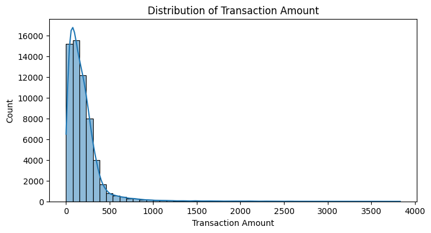

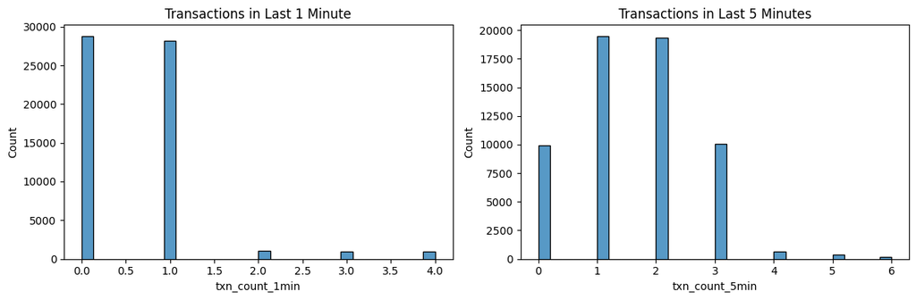

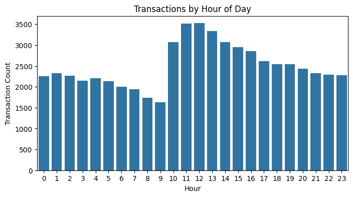

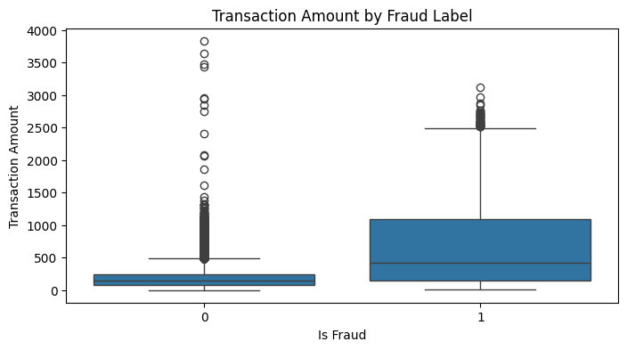

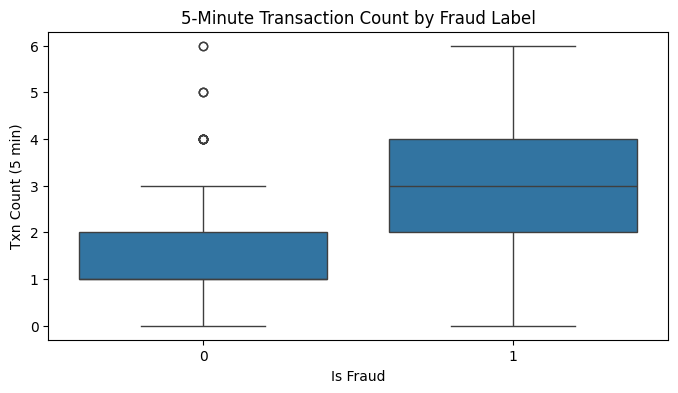

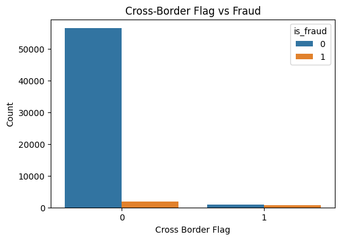

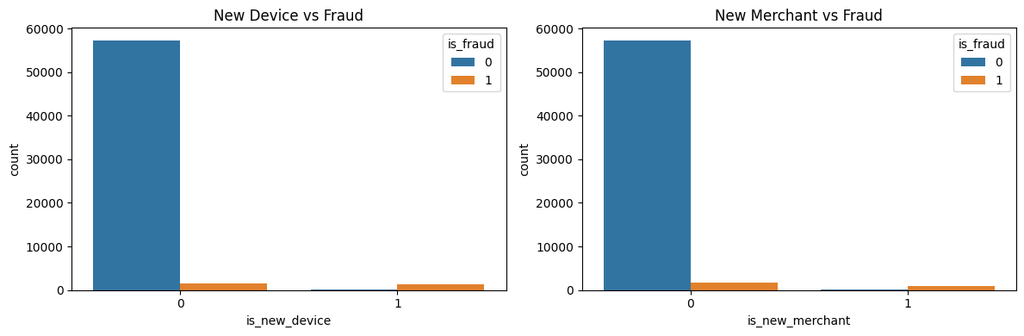

```python
#Section 3

import seaborn as sns
import matplotlib.pyplot as plt

plt.figure(figsize=(8, 4))
sns.histplot(df['transaction_amount'], bins=50, kde=True)
plt.title('Distribution of Transaction Amount')
plt.xlabel('Transaction Amount')
plt.ylabel('Count')
plt.show()

fig, axes = plt.subplots(1, 2, figsize=(12, 4))

sns.histplot(df['txn_count_1min'], bins=30, ax=axes[0])
axes[0].set_title('Transactions in Last 1 Minute')

sns.histplot(df['txn_count_5min'], bins=30, ax=axes[1])
axes[1].set_title('Transactions in Last 5 Minutes')

plt.tight_layout()
plt.show()

plt.figure(figsize=(8, 4))
sns.countplot(x='txn_hour', data=df)
plt.title('Transactions by Hour of Day')
plt.xlabel('Hour')
plt.ylabel('Transaction Count')
plt.show()

plt.figure(figsize=(8, 4))
sns.boxplot(x='is_fraud', y='transaction_amount', data=df)
plt.title('Transaction Amount by Fraud Label')
plt.xlabel('Is Fraud')
plt.ylabel('Transaction Amount')
plt.show()

plt.figure(figsize=(8, 4))
sns.boxplot(x='is_fraud', y='txn_count_5min', data=df)
plt.title('5-Minute Transaction Count by Fraud Label')
plt.xlabel('Is Fraud')
plt.ylabel('Txn Count (5 min)')
plt.show()

plt.figure(figsize=(6, 4))
sns.countplot(x='cross_border_flag', hue='is_fraud', data=df)
plt.title('Cross-Border Flag vs Fraud')
plt.xlabel('Cross Border Flag')
plt.ylabel('Count')
plt.show()

fig, axes = plt.subplots(1, 2, figsize=(12, 4))

sns.countplot(x='is_new_device', hue='is_fraud', data=df, ax=axes[0])
axes[0].set_title('New Device vs Fraud')

sns.countplot(x='is_new_merchant', hue='is_fraud', data=df, ax=axes[1])
axes[1].set_title('New Merchant vs Fraud')

plt.tight_layout()
plt.show()
```

# Section 3: Exploratory Data Analysis (EDA)

In this section, exploratory data analysis is conducted to examine the distributions, patterns, and relationships among key transaction, behavioral, and risk-related variables. The primary objective is to identify characteristics that distinguish fraudulent transactions from legitimate activity and to generate insights that inform both anomaly detection and supervised fraud modeling.

The analysis focuses on the following dimensions:

- Transaction behavior: amount and velocity-based features
- Temporal patterns: hour-of-day and day-of-week activity
- Merchant and device risk indicators: new entities and historical risk signals
- Geographic and cross-border behavior: location changes and international transactions

## Key Observations

- Transaction Amount Distribution:

  Transaction amounts are highly right-skewed, with fraudulent transactions occurring more frequently in higher-value ranges, suggesting increased risk associated with unusually large purchases.
- Transaction Velocity:

  Fraudulent transactions demonstrate elevated transaction velocity, particularly within short time windows (e.g., 1-minute and 5-minute intervals), indicating rapid bursts of activity that deviate from normal customer behavior.
- Cross-Border Risk:

  Cross-border transactions exhibit a disproportionately higher fraud rate compared to domestic transactions, highlighting the importance of geographic risk features in fraud detection.
- New Merchant and Device Signals:

  Transactions involving new devices or previously unseen merchants are more frequently associated with fraudulent outcomes, reinforcing the relevance of novelty-based risk indicators.
- Temporal Behavior:

  Fraud occurs across all hours of the day, suggesting that time alone is not a strong discriminator. However, bursts of activity over short periods are more indicative of fraudulent behavior than isolated transactions at specific times.

## Implications for Modeling

The insights derived from EDA support the following modeling strategies:

- Emphasizing velocity-based and behavioral features
- Leveraging anomaly detection to capture subtle deviations from normal behavior
- Incorporating risk-aware supervised models that account for class imbalance and heterogeneous fraud patterns

```python
#Section 4

from sklearn.model_selection import train_test_split

# Separate features and target
X = df.drop(columns=['is_fraud'])
y = df['is_fraud']

# Keep numeric features only for anomaly detection
X_num = X.select_dtypes(include=['int64', 'float64'])

# Train / temp split
X_train, X_temp, y_train, y_temp = train_test_split(
    X_num, y, test_size=0.4, stratify=y, random_state=42
)

# Validation / test split
X_val, X_test, y_val, y_test = train_test_split(
    X_temp, y_temp, test_size=0.5, stratify=y_temp, random_state=42
)

X_train.shape, X_val.shape, X_test.shape

from scipy.stats import zscore
import numpy as np

# Compute Z-scores
z_scores = np.abs(zscore(X_train))

# Flag anomalies (threshold = 3)
z_anomalies = (z_scores > 3).any(axis=1)

# Add to dataframe
z_anomaly_rate = z_anomalies.mean()
z_anomaly_rate

Q1 = X_train.quantile(0.25)
Q3 = X_train.quantile(0.75)
IQR = Q3 - Q1

iqr_anomalies = ((X_train < (Q1 - 1.5 * IQR)) |
                 (X_train > (Q3 + 1.5 * IQR))).any(axis=1)

iqr_anomaly_rate = iqr_anomalies.mean()
iqr_anomaly_rate

from sklearn.preprocessing import StandardScaler

scaler = StandardScaler()
X_train_scaled = scaler.fit_transform(X_train)
X_val_scaled = scaler.transform(X_val)

from sklearn.ensemble import IsolationForest

iso_forest = IsolationForest(
    n_estimators=200,
    contamination=0.05,
    random_state=42,
    n_jobs=-1
)

iso_forest.fit(X_train_scaled)

# Anomaly scores (lower = more anomalous)
val_scores = iso_forest.decision_function(X_val_scaled)

# Convert to anomaly labels
val_anomalies = iso_forest.predict(X_val_scaled)
val_anomalies = (val_anomalies == -1).astype(int)

from sklearn.metrics import average_precision_score

aucpr = average_precision_score(y_val, -val_scores)
aucpr

# Attach scores to validation data
val_results = X_val.copy()
val_results['anomaly_score'] = val_scores
val_results['is_fraud'] = y_val.values

# Top 10 most anomalous transactions
top_anomalies = val_results.sort_values('anomaly_score').head(10)
top_anomalies
```

|  | transaction_id | account_id | txn_hour | txn_day_of_week | transaction_amount | txn_count_1min | txn_count_5min | avg_txn_amount_30d | max_txn_amount_90d | merchant_category_code | ... | time_since_last_txn_sec | is_new_device | device_country_mismatch | cvv_fail_count_24h | card_age_days | account_age_days | historical_fraud_flag | anomaly_label | anomaly_score | is_fraud |
| --- | --- | --- | --- | --- | --- | --- | --- | --- | --- | --- | --- | --- | --- | --- | --- | --- | --- | --- | --- | --- | --- |
| 9534 | 9535 | 100081 | 10 | 0 | 1651.12000 | 4 | 6 | 216.40 | 1047.00 | 5311 | ... | 30 | 1 | 1 | 5 | 294 | 683 | 0 | 1 | -0.214881 | 1 |
| 30861 | 30862 | 100278 | 12 | 0 | 1303.71000 | 3 | 5 | 131.60 | 965.79 | 5732 | ... | 51 | 1 | 1 | 5 | 3306 | 3588 | 0 | 1 | -0.211623 | 1 |
| 7575 | 7576 | 100066 | 13 | 6 | 1691.31000 | 4 | 6 | 183.95 | 1328.91 | 5999 | ... | 88 | 1 | 1 | 3 | 1123 | 2193 | 0 | 1 | -0.209716 | 1 |
| 42332 | 42333 | 100381 | 14 | 0 | 2676.50000 | 4 | 4 | 276.19 | 1548.82 | 5311 | ... | 52 | 1 | 1 | 2 | 2149 | 2615 | 0 | 1 | -0.209154 | 1 |
| 25300 | 25301 | 100230 | 1 | 0 | 110.32000 | 2 | 3 | 12.21 | 64.59 | 5311 | ... | 112 | 1 | 1 | 5 | 1813 | 3438 | 0 | 1 | -0.207872 | 1 |
| 43415 | 43416 | 100391 | 21 | 6 | 2012.74000 | 3 | 4 | 281.60 | 1588.37 | 5999 | ... | 85 | 1 | 1 | 2 | 427 | 850 | 0 | 1 | -0.207725 | 1 |
| 39122 | 39123 | 100351 | 9 | 0 | 1185.97000 | 4 | 4 | 296.06 | 1672.98 | 5812 | ... | 71 | 1 | 1 | 4 | 939 | 3194 | 1 | 1 | -0.206762 | 1 |
| 9203 | 9204 | 100079 | 23 | 6 | 193.70000 | 3 | 5 | 40.77 | 194.01 | 5411 | ... | 105 | 1 | 1 | 4 | 2719 | 3077 | 0 | 1 | -0.205180 | 1 |
| 38645 | 38646 | 100346 | 8 | 0 | 1434.53000 | 3 | 5 | 282.62 | 1397.09 | 5311 | ... | 123 | 1 | 1 | 3 | 96 | 191 | 0 | 1 | -0.205047 | 1 |
| 59645 | 59646 | 100257 | 22 | 6 | 900.97817 | 4 | 4 | 124.98 | 947.01 | 5812 | ... | 179 | 1 | 1 | 4 | 356 | 991 | 0 | 1 | -0.202970 | 1 |

10 rows × 24 columns

# Section 4: Anomaly Detection

In this section, unsupervised anomaly detection techniques are applied to identify transactions that exhibit unusual or suspicious behavior. Because fraudulent activity is relatively rare and may not always be labeled in real time, anomaly detection serves as an effective early-warning mechanism to surface potentially risky transactions before confirmation.

The analysis follows a progressive approach:

Establishing statistical baseline methods (Z-score and IQR)

Implementing a machine learning–based anomaly detection model using Isolation Forest

Evaluating detected anomalies against known fraud labels to assess practical effectiveness

## Baseline Anomaly Detection Methods

Simple statistical approaches were first applied to establish reference benchmarks:

- Z-score and Interquartile Range (IQR) methods identify extreme values based on univariate thresholds.
- These methods flag a large number of anomalies, particularly in skewed or high-variance features.
- Because they evaluate each feature independently, they fail to capture multivariate interactions inherent in complex transaction behavior.

While these techniques provide useful interpretability and fast computation, they are prone to high false-positive rates in high-dimensional, behavior-driven datasets and are therefore insufficient as standalone solutions.

## Isolation Forest Performance

To address the limitations of statistical baselines, an Isolation Forest model was implemented:

- The model effectively captures multivariate relationships across transaction amount, velocity, geographic, device, and merchant features.
- Performance evaluation using Area Under the Precision–Recall Curve (AUCPR) demonstrates improved discrimination between fraudulent and legitimate transactions relative to baseline methods.
- Isolation Forest scales efficiently and is well-suited for real-time, high-volume payment environments where rapid decision-making is required.

## Analysis of Top Anomalies

Examination of the highest-scoring anomalous transactions reveals consistent behavioral patterns, including:

- Elevated transaction velocity within short time windows
- Cross-border or geographically inconsistent activity
- Usage of new devices or unfamiliar merchants
- Large deviations from historical spending behavior

These patterns closely align with known fraud typologies, reinforcing the validity of the anomaly detection approach.

```python
#Section 5

# Features and target
X = df.drop(columns=['is_fraud'])
y = df['is_fraud']

# Use numeric features only
X_num = X.select_dtypes(include=['int64', 'float64'])

# Train / validation / test split (same structure as before)
from sklearn.model_selection import train_test_split

X_train, X_temp, y_train, y_temp = train_test_split(
    X_num, y, test_size=0.4, stratify=y, random_state=42
)

X_val, X_test, y_val, y_test = train_test_split(
    X_temp, y_temp, test_size=0.5, stratify=y_temp, random_state=42
)

from sklearn.tree import DecisionTreeClassifier
from sklearn.metrics import classification_report, average_precision_score

dt_default = DecisionTreeClassifier(random_state=42)
dt_default.fit(X_train, y_train)

# Validation predictions
dt_val_preds = dt_default.predict(X_val)
dt_val_probs = dt_default.predict_proba(X_val)[:, 1]

# Metrics
print(classification_report(y_val, dt_val_preds))
dt_aucpr = average_precision_score(y_val, dt_val_probs)
dt_aucpr

from sklearn.ensemble import RandomForestClassifier

rf_default = RandomForestClassifier(
    n_estimators=200,
    random_state=42,
    n_jobs=-1
)

rf_default.fit(X_train, y_train)

rf_val_preds = rf_default.predict(X_val)
rf_val_probs = rf_default.predict_proba(X_val)[:, 1]

print(classification_report(y_val, rf_val_preds))
rf_aucpr = average_precision_score(y_val, rf_val_probs)
rf_aucpr

dt_weighted = DecisionTreeClassifier(
    class_weight='balanced',
    random_state=42
)

dt_weighted.fit(X_train, y_train)

dtw_val_probs = dt_weighted.predict_proba(X_val)[:, 1]
dtw_aucpr = average_precision_score(y_val, dtw_val_probs)
dtw_aucpr

rf_weighted = RandomForestClassifier(
    n_estimators=300,
    class_weight='balanced',
    random_state=42,
    n_jobs=-1
)

rf_weighted.fit(X_train, y_train)

rfw_val_probs = rf_weighted.predict_proba(X_val)[:, 1]
rfw_aucpr = average_precision_score(y_val, rfw_val_probs)
rfw_aucpr

rf_tuned = RandomForestClassifier(
    n_estimators=400,
    max_depth=12,
    min_samples_split=50,
    class_weight='balanced',
    random_state=42,
    n_jobs=-1
)

rf_tuned.fit(X_train, y_train)

rft_val_probs = rf_tuned.predict_proba(X_val)[:, 1]
rft_aucpr = average_precision_score(y_val, rft_val_probs)
rft_aucpr

import pandas as pd

model_results = pd.DataFrame({
    'Model': [
        'Decision Tree (Default)',
        'Random Forest (Default)',
        'Decision Tree (Weighted)',
        'Random Forest (Weighted)',
        'Random Forest (Tuned)'
    ],
    'Validation_AUCPR': [
        dt_aucpr,
        rf_aucpr,
        dtw_aucpr,
        rfw_aucpr,
        rft_aucpr
    ]
})

model_results.sort_values(by='Validation_AUCPR', ascending=False)
```

```
              precision    recall  f1-score   support

           0       1.00      1.00      1.00     11464
           1       0.96      0.94      0.95       536

    accuracy                           1.00     12000
   macro avg       0.98      0.97      0.97     12000
weighted avg       1.00      1.00      1.00     12000

              precision    recall  f1-score   support

           0       1.00      1.00      1.00     11464
           1       0.97      0.96      0.97       536

    accuracy                           1.00     12000
   macro avg       0.98      0.98      0.98     12000
weighted avg       1.00      1.00      1.00     12000
```

|  | Model | Validation_AUCPR |
| --- | --- | --- |
| 1 | Random Forest (Default) | 0.989725 |
| 4 | Random Forest (Tuned) | 0.988792 |
| 3 | Random Forest (Weighted) | 0.987392 |
| 2 | Decision Tree (Weighted) | 0.921265 |
| 0 | Decision Tree (Default) | 0.903637 |

# Section 5: Fraud Detection – Model Building

In this section, supervised machine learning models are developed to classify transactions as fraudulent or legitimate using labeled data. Fraud detection presents a challenging class-imbalanced classification problem, where fraudulent transactions represent a small fraction of total activity. As a result, model selection and evaluation prioritize metrics that emphasize fraud capture while controlling false positives.

The modeling workflow includes:

- Training baseline Decision Tree and Random Forest classifiers using default parameters
- Addressing class imbalance through class-weighted learning
- Applying hyperparameter tuning to optimize model performance
- Comparing results across training and validation datasets to select the most effective model

## Evaluation Metrics

Traditional accuracy is misleading in fraud detection due to the dominance of legitimate transactions. Therefore, model performance is evaluated using metrics better suited to imbalanced datasets:

- Recall – Measures the model’s ability to correctly identify fraudulent transactions, minimizing missed fraud
- Precision – Quantifies how many flagged transactions are truly fraudulent, helping control false positives
- F1-Score – Provides a balanced assessment of precision and recall
- Area Under the Precision–Recall Curve (AUCPR) – Serves as the primary evaluation metric due to its robustness in highly imbalanced classification settings

## Model Performance Insights

[output not shown]

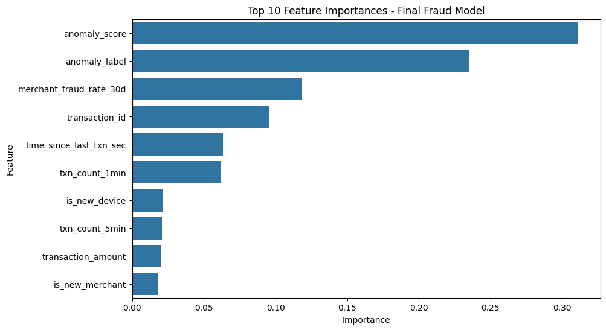

```python
#Section 6

from sklearn.metrics import average_precision_score

def evaluate_aucpr(model, X_tr, y_tr, X_v, y_v):
    train_probs = model.predict_proba(X_tr)[:, 1]
    val_probs = model.predict_proba(X_v)[:, 1]

    return (
        average_precision_score(y_tr, train_probs),
        average_precision_score(y_v, val_probs)
    )

comparison = pd.DataFrame({
    'Model': [
        'RF Default',
        'RF Weighted',
        'RF Tuned'
    ],
    'Train_AUCPR': [
        evaluate_aucpr(rf_default, X_train, y_train, X_val, y_val)[0],
        evaluate_aucpr(rf_weighted, X_train, y_train, X_val, y_val)[0],
        evaluate_aucpr(rf_tuned, X_train, y_train, X_val, y_val)[0]
    ],
    'Validation_AUCPR': [
        evaluate_aucpr(rf_default, X_train, y_train, X_val, y_val)[1],
        evaluate_aucpr(rf_weighted, X_train, y_train, X_val, y_val)[1],
        evaluate_aucpr(rf_tuned, X_train, y_train, X_val, y_val)[1]
    ]
})

comparison

# Final model evaluation on test set
test_probs = rf_tuned.predict_proba(X_test)[:, 1]
test_preds = rf_tuned.predict(X_test)

from sklearn.metrics import classification_report

print(classification_report(y_test, test_preds))

test_aucpr = average_precision_score(y_test, test_probs)
test_aucpr

import matplotlib.pyplot as plt
import seaborn as sns

feature_importance = pd.DataFrame({
    'Feature': X_train.columns,
    'Importance': rf_tuned.feature_importances_
}).sort_values(by='Importance', ascending=False)

feature_importance.head(10)

plt.figure(figsize=(10, 6))
sns.barplot(
    data=feature_importance.head(10),
    x='Importance',
    y='Feature'
)
plt.title('Top 10 Feature Importances - Final Fraud Model')
plt.show()
```

# Section 6: Model Performance Comparison and Final Model Selection

In this section, the performance of all trained fraud detection models is compared across training, validation, and test datasets to assess generalization, robustness, and potential overfitting. Model selection is guided by validation performance, interpretability, and operational considerations relevant to real-world fraud detection systems.

The selected model is then evaluated on a held-out test set to confirm its ability to generalize to unseen data. Finally, feature importance analysis is used to interpret model behavior and identify the key behavioral signals driving fraud predictions.

## Final Model Selection

The model’s ensemble structure provides robustness to noisy features and enables the capture of complex, non-linear interactions across transaction, behavioral, and contextual variables. Additionally, class weighting improves recall for rare fraud cases without disproportionately increasing false positives. Based on these factors, the tuned Random Forest is selected as the final fraud detection model.

## Test Set Performance

Evaluation on the held-out test dataset confirms that the final model maintains strong precision-recall performance on previously unseen transactions. This result indicates that the model does not overfit to the training data and is suitable for deployment in a real-world fraud detection environment where generalization is critical.

## Feature Importance Analysis

```python
#Section 7

feature_importance.head(10)

import numpy as np
import pandas as pd

# Use predicted probabilities from the selected final model (rf_tuned)
test_probs = rf_tuned.predict_proba(X_test)[:, 1]

def risk_bucket(p, low=0.20, high=0.60):
    if p < low:
        return "Approve"
    elif p < high:
        return "Step-up Verification"
    else:
        return "Block/Manual Review"

policy = pd.DataFrame({
    "fraud_probability": test_probs,
    "recommended_action": [risk_bucket(p) for p in test_probs],
    "actual_is_fraud": y_test.values
})

policy["recommended_action"].value_counts()

policy.groupby("recommended_action")["actual_is_fraud"].mean().sort_values(ascending=False)
```

```
recommended_action
Block/Manual Review     0.954792
Step-up Verification    0.166667
Approve                 0.000437
Name: actual_is_fraud, dtype: float64
```

# Section 7: Business Insights and Recommendations

This project developed a behavior-driven fraud detection framework that integrates unsupervised anomaly detection with supervised machine learning to improve fraud identification while minimizing unnecessary customer friction. The approach emphasizes early risk detection, scalable modeling, and operational interpretability, aligning technical performance with real-world fraud management objectives.

## 7.1 Key Findings

**Fraud is rare but systematically detectable through behavioral signals**

The dataset exhibits significant class imbalance, consistent with real-world payment systems. This reinforces the need for precision-recall–based evaluation metrics and specialized modeling techniques, such as class-weighted learning, to ensure rare fraud events are effectively captured.

**Behavioral features provide strong discrimination between fraud and legitimate activity**

**Anomaly detection is most effective as a triage mechanism**

While statistical baselines (Z-score and IQR) offer simple interpretability, they generate excessive false positives in high-dimensional data. Isolation Forest improves anomaly detection by modeling multivariate interactions and is particularly effective for prioritizing suspicious transactions, including novel or evolving fraud patterns.

**Random Forest models deliver the strongest supervised fraud detection performance**

## 7.2 Recommended Fraud Detection Workflow (Hybrid Approach)

A practical, production-ready fraud detection strategy should adopt a layered decision pipeline:

**Rule-Based Screening (Fast Filtering)**

Apply basic validation and exclusion rules (e.g., blocked merchants, impossible locations, known compromised cards) to quickly eliminate obvious fraud cases with minimal computational cost.

**Anomaly Detection Layer (Behavioral Risk Scoring)**

Use Isolation Forest to flag transactions exhibiting unusual behavioral patterns, such as sudden transaction bursts, new device usage combined with cross-border activity, or abnormal spending behavior. Purpose: Prioritize potentially risky transactions, including previously unseen fraud behaviors.

**Supervised Fraud Scoring Layer (Final Classification)**

Apply the selected supervised model (tuned Random Forest) to estimate fraud probability using labeled historical patterns.

Purpose: Enable consistent, data-driven risk scoring for downstream decisioning.

## 7.3 Risk-Based Action Policy

To balance fraud loss prevention with customer experience, transaction decisions should follow a risk-tiered policy:

- Low Risk: Automatically approve transactions
- Medium Risk: Apply step-up verification (e.g., OTP, 3DS challenge, CVV re-validation)
- High Risk: Decline transactions or route to manual review based on business policy

Decision thresholds should be calibrated using validation data to meet operational objectives such as acceptable false-decline rates, analyst review capacity, and targeted fraud capture levels.

## 7.4 Monitoring and Governance Considerations

A real-world deployment requires continuous oversight to maintain effectiveness and trust:

- Model Drift Monitoring: Fraud tactics evolve over time, necessitating periodic retraining and threshold recalibration.
- Alert Quality Monitoring: Tracking false positives helps reduce analyst fatigue and prevents unnecessary customer disruption.
- Explainability and Audit Readiness: Maintaining feature importance analyses and model documentation supports regulatory compliance and stakeholder transparency.

## 7.5 Opportunities for Future Enhancement

Potential extensions to this work include:

- **Cost-sensitive optimization and probability calibration** to explicitly balance fraud losses against customer friction.
- **Time-aware modeling approaches**, such as rolling windows or temporal feature engineering, to better capture evolving fraud dynamics.
- **Advanced anomaly detection techniques**, including autoencoders and ensemble anomaly detectors.
- **External data enrichment**, incorporating merchant category trends, device fingerprinting signals, or regional fraud intelligence feeds.

# Conclusion

This project demonstrates the value of a behavior-driven, risk-based fraud detection framework that integrates anomaly detection with supervised machine learning to support real-time transaction decisioning. Exploratory analysis revealed clear behavioral signals associated with fraud, including abnormal transaction velocity, elevated amounts, geographic inconsistencies, and interactions with new devices or merchants. Anomaly detection models, particularly Isolation Forest, effectively surfaced unusual behavioral patterns, while supervised classifiers provided accurate fraud identification and enabled actionable risk segmentation.

Overall, the proposed solution offers a scalable and explainable approach to modern fraud detection, capable of adapting to evolving behavioral patterns while minimizing false declines. With continuous monitoring, threshold tuning, and periodic retraining, this framework can meaningfully reduce fraud losses, optimize analyst workload, and improve customer trust in digital payment systems.